# Graduate Attribute Course Report: ENGR 300

Jake Kaupp

2016-06-21

# 1 Introduction

The following is a program-level report on the Graduate Attribute Assessment and Continuous Improvement Process efforts in ENGR. It should help provide a view into the performance of each cohort and potentially reveal some aspects of the program that could be considered for future improvement.

# 2 Graduate Attribute Overview

The following chart represents the aggregate student performance on each indicator for each graduate attribute assessed in the course. Each data point represents the mean score achieved for a single indicator for each repsective attribute. The points are jittered to reduce overplotting, with dividing lines showing the bounds for each performance category.

[interactive chart not shown]

# 3 ENGR 300 Graduate Attribute Assessment Focus

This chart represents the assessment focus of course, presenting the attributes and indicators assessed in the course and how many times they are assessed. The larger the attribute grouping (area by color) the more indicators are assessed for that attribute. The larger the area of the individual indicator boxes, the more times that indicator is assessed in the course.

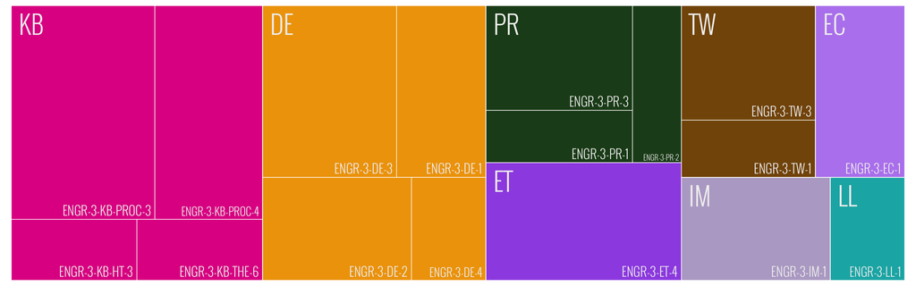

# 4 ENGR 300 Gradaute Attribute Mapping & Student Performance

The following table presents course mapping information integrated with histograms depicting student performance for each separate assessment of a particular indicator. The mapping information provides a detailed view of how attributes and indicators are mapped to and assessed in a course. It provides contextual information such as assessor, context, date and any instructor comments made regarding the assessment data. Missing items are labeled as “NA”.

The small histograms (sparklines) are aggregates of student performance on the indicators asessed in the course. The distributions are presented percentages of the cohort attaining a paricular level. The histograms are interactive and will display the the performance level and percentage on mouseover.

| Indicator | Description | Assessment | Assessor | Date Assessed | Instructor Comments | Students Assessed | 2014-2015 | 2015-2016 |
| --- | --- | --- | --- | --- | --- | --- | --- | --- |
| ENGR-3-DE-1 | Identifies problem, objectives and constraints including health and safety, environmental and societal issues and/or user needs | Design Challenge 1:Definition-Objectives |  | 1 |  | 119 | 1,0,6,48,45 | 3,10,21,26,40 |
| ENGR-3-DE-1 | Identifies problem, objectives and constraints including health and safety, environmental and societal issues and/or user needs | Design Challenge 3 report:Description-Objectives |  | 4 |  | 120 | 1,0,6,48,45 | 3,10,21,26,40 |
| ENGR-3-DE-2 | Produces multiple potential solutions to meet functional specifications and compares solutions to select best concept | Design Challenge 1:Process selection |  | 1 |  | 119 | 1,0,6,48,45 | 1,0,18,56,25 |
| ENGR-3-DE-2 | Produces multiple potential solutions to meet functional specifications and compares solutions to select best concept | Tutorial 2:Table 2 |  | 1 |  | 120 | 1,0,6,48,45 | 1,0,18,56,25 |
| ENGR-3-DE-3 | Develops equipment, process or product design incorporating performance requirements and constraints such as quality, yield, reliability, economics, safety, and standards and codes as appropriate. | Design Challenge 3 report:Detailed specifications |  | 4 |  | 120 | 1,0,0,17,81 | 2,4,3,28,63 |
| ENGR-3-DE-3 | Develops equipment, process or product design incorporating performance requirements and constraints such as quality, yield, reliability, economics, safety, and standards and codes as appropriate. | Design Challenge 4:Design Challenge 4 report |  | 8 |  | 119 | 1,0,0,17,81 | 2,4,3,28,63 |
| ENGR-3-DE-3 | Develops equipment, process or product design incorporating performance requirements and constraints such as quality, yield, reliability, economics, safety, and standards and codes as appropriate. | Tutorial 8:Week 8 tutorial |  | 7 |  | 119 | 1,0,0,17,81 | 2,4,3,28,63 |
| ENGR-3-DE-4 | Creates and tests simulations, models, and/or prototypes at various points in design with complexity appropriate to design stage | Design Challenge 3 report:Simulations |  | 4 |  | 120 | 0,0,0,0,0 | 9,11,24,31,25 |
| ENGR-3-EC-1 | Applies economic considerations, such as capital and operating costs, to design processes. | Design Challenge 3 initial submissions:Optimization submission |  | 3 |  | 120 | 0,0,0,54,46 | 3,0,8,7,82 |
| ENGR-3-EC-1 | Applies economic considerations, such as capital and operating costs, to design processes. | Design Challenge 3 report:Costing |  | 4 |  | 102 | 0,0,0,54,46 | 3,0,8,7,82 |

[output cut: 22 more lines]

# 5 Instructor Interpretation & Feedback

Part of CEAB’s requirements is to demonstrate the use of outcomes assessment data to make improvements to the course, program and process. The Faculty is supporting all departments in thei accreditation efforts. In order to have some consistent information about data-informed improvement and to help prepare future accreditation reports, [**the Faculty would like you to follow this link and complete a short survey**](http://queensu.fluidsurveys.com/s/CHEE/RM/).